# Distribution of minimum annual income growth rates

Use `sample_growth_tb` to compare distributions of minimum annual growth rates between individuals with high income growth over 2014–2020 (HGF) and all others (non-HGF). Use six-year log growth to identify high-growth individuals.

## 0 Data preparation

```r
library(tidyverse)
library(pins)
library(matrixStats)
# Specify relative paths for the board, figure output directory, and plotting theme.
board <- board_folder("../income_board_replicate")
graph_dir <- "graph"
dir.create(graph_dir, recursive = TRUE, showWarnings = FALSE)
source("theme_ipsum_like.R")
theme_set(theme_ipsum())
```

**Data loading and sample selection**

Load `sample_growth_tb` and extract six annual growth rates from 2014–15 through 2019–20 and growth over 2014–2020 (`g_20_14`). Select individuals meeting the following conditions.

- Income in 2014 of at least $4\times10^6$ yen (4 million yen)
- Age in 2014 between 25 and 60, inclusive

```r
sample_growth_tb <- board |> pin_read("sample_growth_tb") |>
  filter(year %in% c("g_20_19", "g_19_18", "g_18_17", "g_17_16", "g_16_15", "g_15_14", "g_20_14"))

growth_wide_tb <- sample_growth_tb |>
  pivot_wider(id_cols = id, names_from = year, values_from = growth) |>
  inner_join(sample_growth_tb |> filter(year == "g_15_14") |>
               mutate(age = as.numeric(str_c(20, str_sub(year,6,7))) - as.numeric(str_sub(birth_date, 1, 4))) |>
               select(id, pre_income, age), by = "id") |>
  filter(pre_income >= 4*10^6,
         age >= 25, age <= 60) |>
  na.omit() |>
  select(-pre_income, -age)
```

## 1 Comparing minimum growth rates

**Checking upper percentiles**

Using `growth_wide_tb` after sample selection and removal of missing values, inspect the 90th, 95th, 97th, and 99th percentiles of six-year growth `g_20_14`. Use the 97th percentile of this full sample for the subsequent high-growth classification.

```r
growth_wide_tb |>
  summarise(q_90 = quantile(g_20_14, 0.90, na.rm = T),
            q_95 = quantile(g_20_14, 0.95, na.rm = T),
            q_97 = quantile(g_20_14, 0.97, na.rm = T),
            q_99 = quantile(g_20_14, 0.99, na.rm = T))
```

| q_90 | q_95 | q_97 | q_99 |
| --- | --- | --- | --- |
| 0.577607 | 0.8540304 | 1.072491 | 1.584053 |

**Creating the minimum-growth table `compare_smallest_tb`**

Classify individuals whose `g_20_14` is strictly above the 97th percentile as HGF and all others as non-HGF, adding the indicator `hg`. Use `add_smallest()` to calculate each individual’s minimum growth rate and store it in `smallest_1st`. Use the following periods for each group.

- non-HGF: five periods from 2014–15 through 2018–19
- HGF: six periods from 2014–15 through 2019–20

```r
temp_tb <- growth_wide_tb |>
  mutate(hg = if_else(g_20_14 > quantile(g_20_14, 0.97, na.rm = T), "HGF", "non-HGF"))

add_smallest <- function(df, growth_cols) {
  growth_matrix <- df |>
    select(all_of(growth_cols)) |>
    as.matrix()

  df |> mutate(smallest_1st = rowOrderStats(growth_matrix, which = 1))
}

annual_cols <- c(
  "g_20_19", "g_19_18", "g_18_17",
  "g_17_16", "g_16_15", "g_15_14"
)

compare_smallest_tb <- bind_rows(
  temp_tb |>
    filter(hg == "non-HGF") |>
    add_smallest(annual_cols[-1]),
  temp_tb |>
    filter(hg == "HGF") |>
    add_smallest(annual_cols)
)
```

**Visual comparison of distributions**

Compare densities of minimum growth `smallest_1st` between HGF and non-HGF. Estimate densities using only observations with $|\mathrm{smallest\_1st}| < 3$, and display a horizontal range of −1.5 to 1.5.

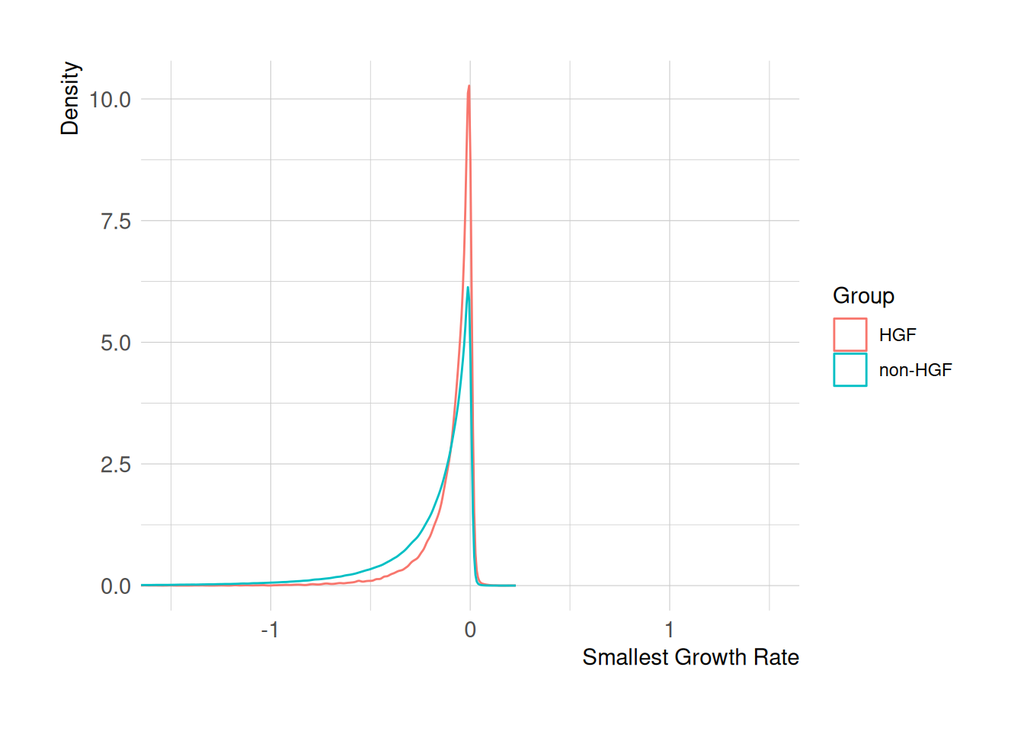

```r
compare_smallest_tb |>
  filter(abs(smallest_1st) < 3) |>
ggplot() +
  geom_density(aes(smallest_1st, color = hg)) +
  coord_cartesian(xlim = c(-1.5,1.5)) +
  labs(
    x = "Smallest Growth Rate",
    y = "Density",
    color = "Group"
  )
ggsave(filename = "compare_smallest_growth_income.png", path = graph_dir)
```

```r
compare_smallest_tb |>
  group_by(hg) |>
  summarise(median(smallest_1st), mean(smallest_1st), n_obs = n())
```

| hg | median(smallest_1st) | mean(smallest_1st) | n_obs |
| --- | --- | --- | --- |
| HGF | -0.04884312 | -0.09416995 | 26763 |
| non-HGF | -0.10669857 | -0.20164980 | 865310 |